# Preferences in Blending

Rafael Peñaloza

2025-01-20

We use the clean data (constructed before) to verify respondent-wise differences and check statistically significant differences (or lack thereof)

## Load

Load the data and construct the differences

# Easy Case

The simplest test is to see how often one method is preferred over another. If two methods are equally good, one expects that *half* of the time one is preferred over the other. We see this as a Bernoulli experiment, and try to verify whether its parameter (the probability that one is preferred over another) is greater or less than 0.5.

We do this for every possible pair, thus obtaining a partial order.

General

| Test | Positive | Negative | Proportion |
| --- | --- | --- | --- |
| ALTERNATE > SWITCH | 0.314493177206736 | 0.700266890006387 | 0.494704324801412 |
| ALTERNATE > TEXTUAL | 1.11098762831845e-20 | 1 | 0.402912621359223 |
| ALTERNATE > UNET | 1.70383333555758e-11 | 0.99999999998721 | 0.43027360988526 |
| SWITCH > TEXTUAL | 4.24764229995022e-24 | 1 | 0.394527802294793 |
| SWITCH > UNET | 5.53138205151186e-15 | 0.999999999999996 | 0.418799646954987 |
| TEXTUAL > UNET | 0.999997927937159 | 2.53452781812465e-06 | 0.548102383053839 |

This table shows the p-values for the comparisons between methods. For a pair “Method1 > Method2” the “Positive” column uses the null-hypothesis H<sub>0</sub>:*“Method2 is preferred over Method1.”* If its p-value is small enough, then we can **reject** this null-hypothesis, and consider it evidence for its alternative hypothesis (*Method1 is preferred over Method2*).

Dually, the “Negative” column uses the null-hypothesis H<sub>0</sub>:*“Method1 is preferred over Method2.”*

So, the first row expresses that there is no statistical evidence to conclude that ALTERNATE is preferred over SWITCH (or *vice-versa*) in general, but from the remaining rows we see that both ALTERNATE and SWITCH are preferred over TEXTUAL and UNET, and that UNET is preferred over TEXTUAL. All these hold with extreme statistical significance (p-value essentially 0).

In other words, ALTERNATE and SWITCH are tied first, followed by UNET, and with TEXTUAL at the end.

We draw a heatmap. In it, only the **white** squares represent a statistically significant difference.

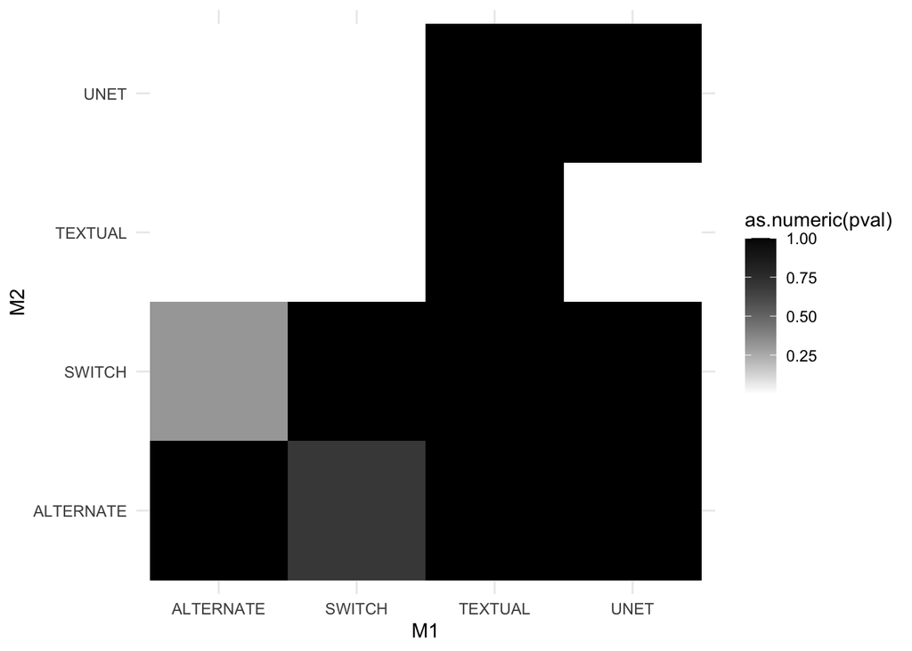

We repeat the same analysis divided by type.

Architecture

| Test | Positive | Negative | Proportion |
| --- | --- | --- | --- |
| ALTERNATE > SWITCH | 0.930504885773488 | 0.0860276068899344 | 0.540453074433657 |
| ALTERNATE > TEXTUAL | 6.9770139361695e-06 | 0.999995905114709 | 0.375404530744337 |
| ALTERNATE > UNET | 0.0860276068899344 | 0.930504885773488 | 0.459546925566343 |
| SWITCH > TEXTUAL | 2.67533163514976e-11 | 0.999999999987961 | 0.313915857605178 |
| SWITCH > UNET | 0.00837044821810306 | 0.993905960433409 | 0.43042071197411 |
| TEXTUAL > UNET | 0.99896158400316 | 0.00151625630112102 | 0.585760517799353 |

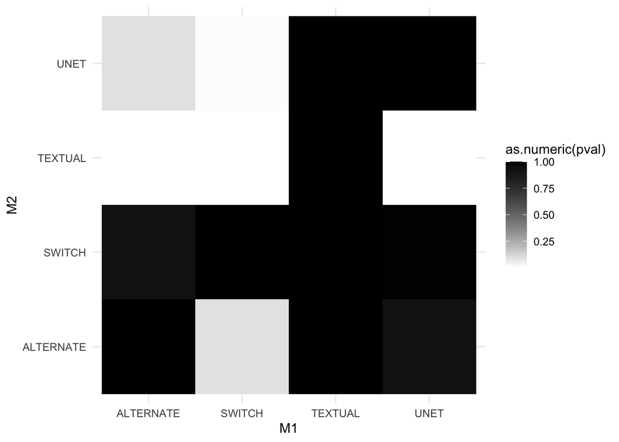

Different

| Test | Positive | Negative | Proportion |
| --- | --- | --- | --- |
| ALTERNATE > SWITCH | 0.96106764702318 | 0.0469701355205213 | 0.537864077669903 |
| ALTERNATE > TEXTUAL | 1.20523588176613e-08 | 0.999999992823549 | 0.376699029126214 |
| ALTERNATE > UNET | 0.00100467612281878 | 0.999256954883597 | 0.431067961165049 |
| SWITCH > TEXTUAL | 1.1077920291726e-05 | 0.999992574691792 | 0.405825242718447 |
| SWITCH > UNET | 1.1077920291726e-05 | 0.999992574691792 | 0.405825242718447 |
| TEXTUAL > UNET | 0.967948914092967 | 0.0389323529768202 | 0.539805825242718 |

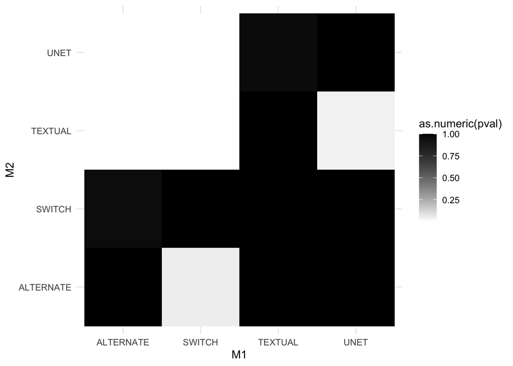

Existing

| Test | Positive | Negative | Proportion |
| --- | --- | --- | --- |
| ALTERNATE > SWITCH | 0.268666309126561 | 0.759590694407835 | 0.485436893203884 |
| ALTERNATE > TEXTUAL | 0.021278890406541 | 0.982841402308136 | 0.454368932038835 |
| ALTERNATE > UNET | 0.953029864479479 | 0.0562858918577815 | 0.535922330097087 |
| SWITCH > TEXTUAL | 1.20523588176613e-08 | 0.999999992823549 | 0.376699029126214 |
| SWITCH > UNET | 0.0792235259263719 | 0.933000988354369 | 0.467961165048544 |
| TEXTUAL > UNET | 0.999999966816668 | 5.44032768328018e-08 | 0.61747572815534 |

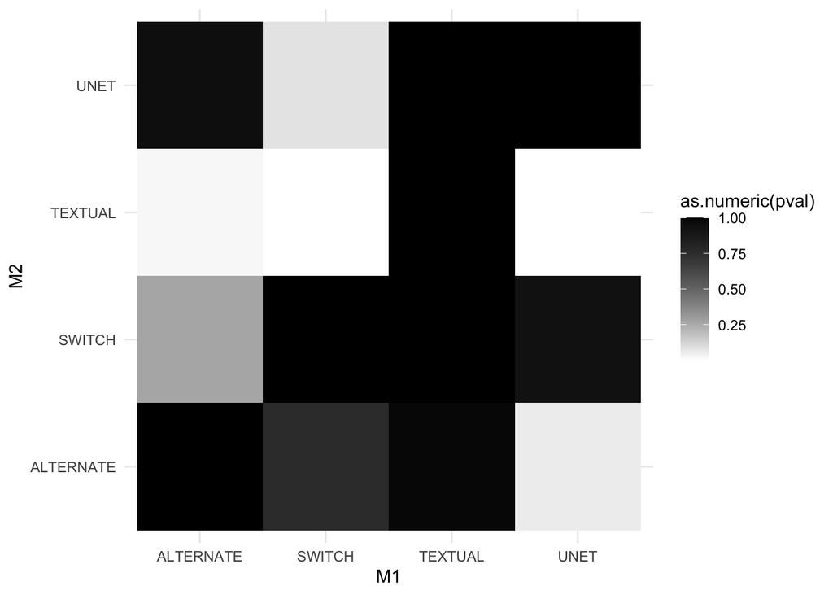

Same

| Test | Positive | Negative | Proportion |
| --- | --- | --- | --- |
| ALTERNATE > SWITCH | 0.998651566545882 | 0.00179654568956115 | 0.56504854368932 |
| ALTERNATE > TEXTUAL | 0.999256954883597 | 0.00100467612281878 | 0.568932038834951 |
| ALTERNATE > UNET | 7.42530820826117e-06 | 0.999995061323471 | 0.403883495145631 |
| SWITCH > TEXTUAL | 0.329753115287528 | 0.701500599492502 | 0.489320388349515 |
| SWITCH > UNET | 4.91198682100804e-19 | 1 | 0.306796116504854 |
| TEXTUAL > UNET | 7.25175194661493e-21 | 1 | 0.297087378640777 |

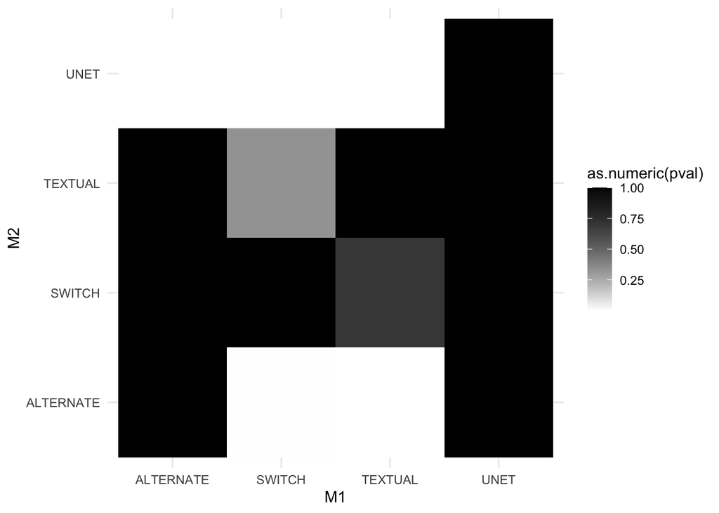

Style

| Test | Positive | Negative | Proportion |
| --- | --- | --- | --- |
| ALTERNATE > SWITCH | 2.34954655192167e-12 | 0.999999999998858 | 0.330097087378641 |
| ALTERNATE > TEXTUAL | 2.16848516739307e-40 | 1 | 0.184466019417476 |
| ALTERNATE > UNET | 2.39937766085784e-15 | 0.999999999999999 | 0.308252427184466 |
| SWITCH > TEXTUAL | 1.42377377156773e-10 | 0.999999999926229 | 0.344660194174757 |
| SWITCH > UNET | 0.597269323061718 | 0.441262124632561 | 0.504854368932039 |
| TEXTUAL > UNET | 1 | 9.20207448197727e-27 | 0.757281553398058 |

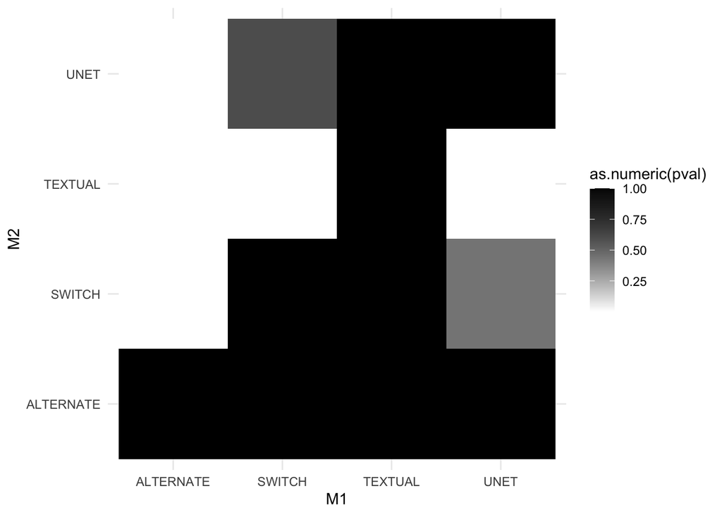